# Breast Cancer Wisconsin (Diagnostic) Data Set

## Preliminary Wrangling

### About the data set:

The data set is from : https://www.kaggle.com/uciml/breast-cancer-wisconsin-data  
(The next line are from the description on Kaggle site:)  
Description

Features are computed from a digitized image of a fine needle aspirate (FNA) of a breast mass. They describe characteristics of the cell nuclei present in the image. n the 3-dimensional space is that described in: [K. P. Bennett and O. L. Mangasarian: "Robust Linear Programming Discrimination of Two Linearly Inseparable Sets", Optimization Methods and Software 1, 1992, 23-34].

This database is also available through the UW CS ftp server: ftp ftp.cs.wisc.edu cd math-prog/cpo-dataset/machine-learn/WDBC/

Also can be found on UCI Machine Learning Repository: https://archive.ics.uci.edu/ml/datasets/Breast+Cancer+Wisconsin+%28Diagnostic%29

Attribute Information:

1) ID number  
2) Diagnosis (M = malignant, B = benign)  
3-32)

Ten real-valued features are computed for each cell nucleus:

a) radius (mean of distances from center to points on the perimeter)  
b) texture (standard deviation of gray-scale values)  
c) perimeter  
d) area  
e) smoothness (local variation in radius lengths)  
f) compactness (perimeter^2 / area - 1.0)  
g) concavity (severity of concave portions of the contour)  
h) concave points (number of concave portions of the contour)  
i) symmetry  
j) fractal dimension ("coastline approximation" - 1)

The mean, standard error and "worst" or largest (mean of the three largest values) of these features were computed for each image, resulting in 30 features. For instance, field 3 is Mean Radius, field 13 is Radius SE, field 23 is Worst Radius.

All feature values are recoded with four significant digits.

Missing attribute values: none

Class distribution: 357 benign, 212 malignant

```python
# import all packages and set plots to be embedded inline
import numpy as np
import pandas as pd
import matplotlib.pyplot as plt
import seaborn as sns

%matplotlib inline

pd.set_option('display.max_columns', None)
pd.set_option('display.max_rows', None)
```

```python
df = pd.read_csv("data.csv")
df.head(2)
```

|  | id | diagnosis | radius_mean | texture_mean | perimeter_mean | area_mean | smoothness_mean | compactness_mean | concavity_mean | concave points_mean | symmetry_mean | fractal_dimension_mean | radius_se | texture_se | perimeter_se | area_se | smoothness_se | compactness_se | concavity_se | concave points_se | symmetry_se | fractal_dimension_se | radius_worst | texture_worst | perimeter_worst | area_worst | smoothness_worst | compactness_worst | concavity_worst | … |
| --- | --- | --- | --- | --- | --- | --- | --- | --- | --- | --- | --- | --- | --- | --- | --- | --- | --- | --- | --- | --- | --- | --- | --- | --- | --- | --- | --- | --- | --- | --- |
| 0 | 842302 | M | 17.99 | 10.38 | 122.8 | 1001.0 | 0.11840 | 0.27760 | 0.3001 | 0.14710 | 0.2419 | 0.07871 | 1.0950 | 0.9053 | 8.589 | 153.40 | 0.006399 | 0.04904 | 0.05373 | 0.01587 | 0.03003 | 0.006193 | 25.38 | 17.33 | 184.6 | 2019.0 | 0.1622 | 0.6656 | 0.7119 | … |
| 1 | 842517 | M | 20.57 | 17.77 | 132.9 | 1326.0 | 0.08474 | 0.07864 | 0.0869 | 0.07017 | 0.1812 | 0.05667 | 0.5435 | 0.7339 | 3.398 | 74.08 | 0.005225 | 0.01308 | 0.01860 | 0.01340 | 0.01389 | 0.003532 | 24.99 | 23.41 | 158.8 | 1956.0 | 0.1238 | 0.1866 | 0.2416 | … |

### What is/are the main feature(s) of interest in your dataset?

> I want to find the most influential parameters on malignancy.

### What features in the dataset do you think will help support your investigation into your feature(s) of interest?

> The dataset have data about size and shape of chest tumors, so we could try and found the most influential parameters.

```python
df.drop(columns=["Unnamed: 32"],inplace=True)
```

```python
df.shape
```

```
(569, 32)
```

```python
df.columns
```

```
Index(['id', 'diagnosis', 'radius_mean', 'texture_mean', 'perimeter_mean',
       'area_mean', 'smoothness_mean', 'compactness_mean', 'concavity_mean',
       'concave points_mean', 'symmetry_mean', 'fractal_dimension_mean',
       'radius_se', 'texture_se', 'perimeter_se', 'area_se', 'smoothness_se',
       'compactness_se', 'concavity_se', 'concave points_se', 'symmetry_se',
       'fractal_dimension_se', 'radius_worst', 'texture_worst',
       'perimeter_worst', 'area_worst', 'smoothness_worst',
       'compactness_worst', 'concavity_worst', 'concave points_worst',
       'symmetry_worst', 'fractal_dimension_worst'],
      dtype='object')
```

```python
df.info()
```

```
<class 'pandas.core.frame.DataFrame'>
RangeIndex: 569 entries, 0 to 568
Data columns (total 32 columns):
 #   Column                   Non-Null Count  Dtype
---  ------                   --------------  -----
 0   id                       569 non-null    int64
 1   diagnosis                569 non-null    object
 2   radius_mean              569 non-null    float64
 3   texture_mean             569 non-null    float64
 4   perimeter_mean           569 non-null    float64
 5   area_mean                569 non-null    float64
 6   smoothness_mean          569 non-null    float64
 7   compactness_mean         569 non-null    float64
 8   concavity_mean           569 non-null    float64
 9   concave points_mean      569 non-null    float64
```

[output cut: 24 more lines]

```python
df.describe().transpose()
```

|  | count | mean | std | min | 25% | 50% | 75% | max |
| --- | --- | --- | --- | --- | --- | --- | --- | --- |
| id | 569.0 | 3.037183e+07 | 1.250206e+08 | 8670.000000 | 869218.000000 | 906024.000000 | 8.813129e+06 | 9.113205e+08 |
| radius_mean | 569.0 | 1.412729e+01 | 3.524049e+00 | 6.981000 | 11.700000 | 13.370000 | 1.578000e+01 | 2.811000e+01 |
| texture_mean | 569.0 | 1.928965e+01 | 4.301036e+00 | 9.710000 | 16.170000 | 18.840000 | 2.180000e+01 | 3.928000e+01 |
| perimeter_mean | 569.0 | 9.196903e+01 | 2.429898e+01 | 43.790000 | 75.170000 | 86.240000 | 1.041000e+02 | 1.885000e+02 |
| area_mean | 569.0 | 6.548891e+02 | 3.519141e+02 | 143.500000 | 420.300000 | 551.100000 | 7.827000e+02 | 2.501000e+03 |
| smoothness_mean | 569.0 | 9.636028e-02 | 1.406413e-02 | 0.052630 | 0.086370 | 0.095870 | 1.053000e-01 | 1.634000e-01 |
| compactness_mean | 569.0 | 1.043410e-01 | 5.281276e-02 | 0.019380 | 0.064920 | 0.092630 | 1.304000e-01 | 3.454000e-01 |
| concavity_mean | 569.0 | 8.879932e-02 | 7.971981e-02 | 0.000000 | 0.029560 | 0.061540 | 1.307000e-01 | 4.268000e-01 |
| concave points_mean | 569.0 | 4.891915e-02 | 3.880284e-02 | 0.000000 | 0.020310 | 0.033500 | 7.400000e-02 | 2.012000e-01 |
| symmetry_mean | 569.0 | 1.811619e-01 | 2.741428e-02 | 0.106000 | 0.161900 | 0.179200 | 1.957000e-01 | 3.040000e-01 |
| fractal_dimension_mean | 569.0 | 6.279761e-02 | 7.060363e-03 | 0.049960 | 0.057700 | 0.061540 | 6.612000e-02 | 9.744000e-02 |
| radius_se | 569.0 | 4.051721e-01 | 2.773127e-01 | 0.111500 | 0.232400 | 0.324200 | 4.789000e-01 | 2.873000e+00 |
| texture_se | 569.0 | 1.216853e+00 | 5.516484e-01 | 0.360200 | 0.833900 | 1.108000 | 1.474000e+00 | 4.885000e+00 |
| perimeter_se | 569.0 | 2.866059e+00 | 2.021855e+00 | 0.757000 | 1.606000 | 2.287000 | 3.357000e+00 | 2.198000e+01 |
| area_se | 569.0 | 4.033708e+01 | 4.549101e+01 | 6.802000 | 17.850000 | 24.530000 | 4.519000e+01 | 5.422000e+02 |
| smoothness_se | 569.0 | 7.040979e-03 | 3.002518e-03 | 0.001713 | 0.005169 | 0.006380 | 8.146000e-03 | 3.113000e-02 |
| compactness_se | 569.0 | 2.547814e-02 | 1.790818e-02 | 0.002252 | 0.013080 | 0.020450 | 3.245000e-02 | 1.354000e-01 |
| concavity_se | 569.0 | 3.189372e-02 | 3.018606e-02 | 0.000000 | 0.015090 | 0.025890 | 4.205000e-02 | 3.960000e-01 |
| concave points_se | 569.0 | 1.179614e-02 | 6.170285e-03 | 0.000000 | 0.007638 | 0.010930 | 1.471000e-02 | 5.279000e-02 |
| symmetry_se | 569.0 | 2.054230e-02 | 8.266372e-03 | 0.007882 | 0.015160 | 0.018730 | 2.348000e-02 | 7.895000e-02 |
| fractal_dimension_se | 569.0 | 3.794904e-03 | 2.646071e-03 | 0.000895 | 0.002248 | 0.003187 | 4.558000e-03 | 2.984000e-02 |
| radius_worst | 569.0 | 1.626919e+01 | 4.833242e+00 | 7.930000 | 13.010000 | 14.970000 | 1.879000e+01 | 3.604000e+01 |
| texture_worst | 569.0 | 2.567722e+01 | 6.146258e+00 | 12.020000 | 21.080000 | 25.410000 | 2.972000e+01 | 4.954000e+01 |
| perimeter_worst | 569.0 | 1.072612e+02 | 3.360254e+01 | 50.410000 | 84.110000 | 97.660000 | 1.254000e+02 | 2.512000e+02 |
| area_worst | 569.0 | 8.805831e+02 | 5.693570e+02 | 185.200000 | 515.300000 | 686.500000 | 1.084000e+03 | 4.254000e+03 |
| smoothness_worst | 569.0 | 1.323686e-01 | 2.283243e-02 | 0.071170 | 0.116600 | 0.131300 | 1.460000e-01 | 2.226000e-01 |
| compactness_worst | 569.0 | 2.542650e-01 | 1.573365e-01 | 0.027290 | 0.147200 | 0.211900 | 3.391000e-01 | 1.058000e+00 |
| concavity_worst | 569.0 | 2.721885e-01 | 2.086243e-01 | 0.000000 | 0.114500 | 0.226700 | 3.829000e-01 | 1.252000e+00 |
| concave points_worst | 569.0 | 1.146062e-01 | 6.573234e-02 | 0.000000 | 0.064930 | 0.099930 | 1.614000e-01 | 2.910000e-01 |
| symmetry_worst | 569.0 | 2.900756e-01 | 6.186747e-02 | 0.156500 | 0.250400 | 0.282200 | 3.179000e-01 | 6.638000e-01 |
| fractal_dimension_worst | 569.0 | 8.394582e-02 | 1.806127e-02 | 0.055040 | 0.071460 | 0.080040 | 9.208000e-02 | 2.075000e-01 |

```python
df["id"].duplicated().sum()
```

```
0
```

## Univariate Exploration

- I'll start by looking at the distribution of the main variable of interest: diagnosis.

```
B    357
M    212
Name: diagnosis, dtype: int64
```

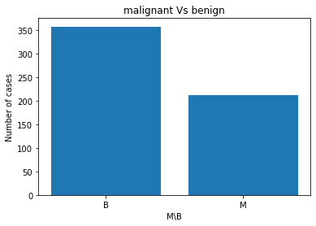

```python
diag = df["diagnosis"].value_counts()
print(diag)

plt.bar(diag.index,diag.values, align='center')
# plt.xticks(y_pos, objects)
plt.ylabel('Number of cases')
plt.xlabel('M\B')
plt.title('malignant Vs benign')
```

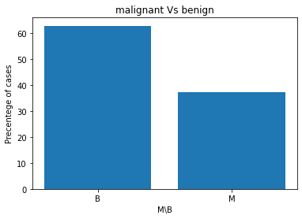

```python
# we could normalize
plt.bar(diag.index,diag.values/diag.sum()*100, align='center');
# plt.xticks(y_pos, objects)
plt.ylabel('Precentege of cases')
plt.xlabel('M\B')
plt.title('malignant Vs benign')
```

### conclusion: more than 60 precent of the case are benign !

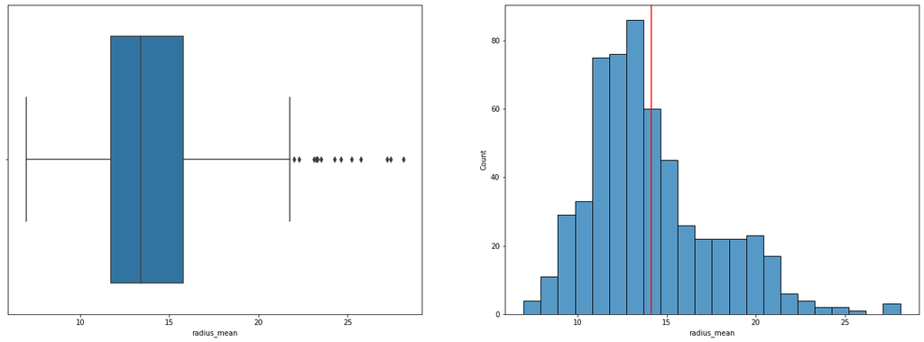

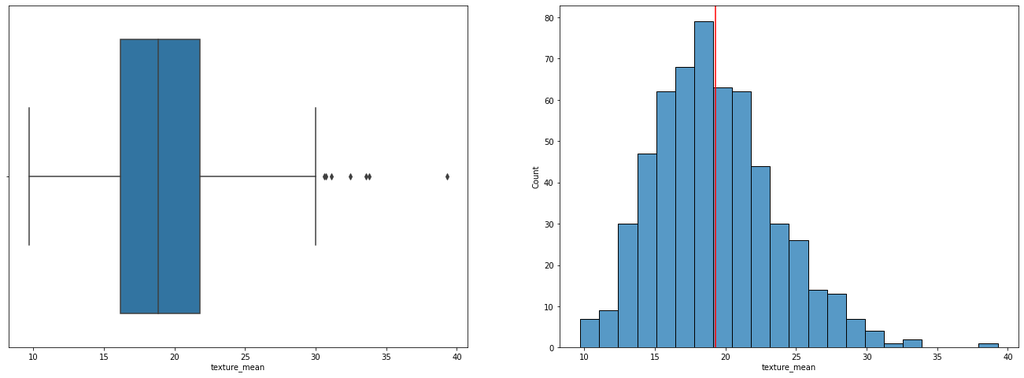

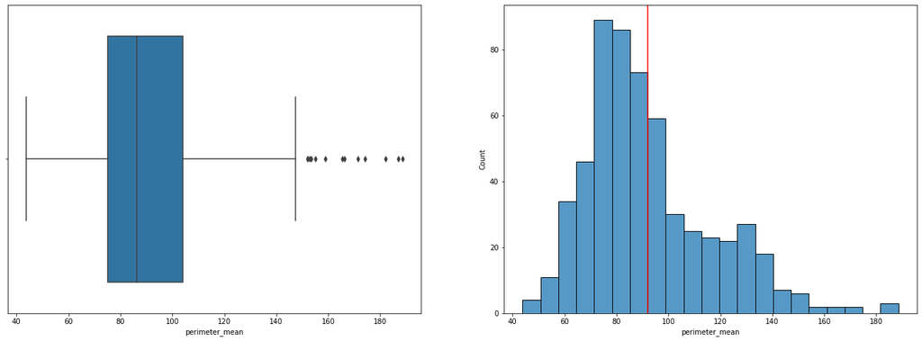

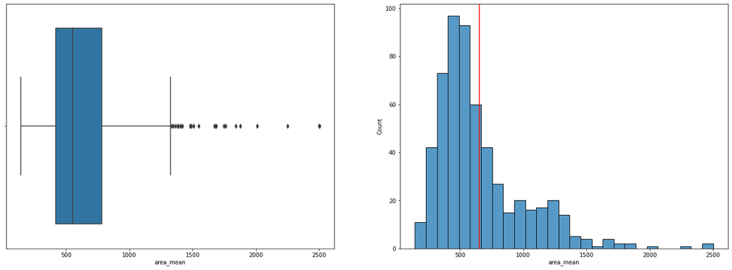

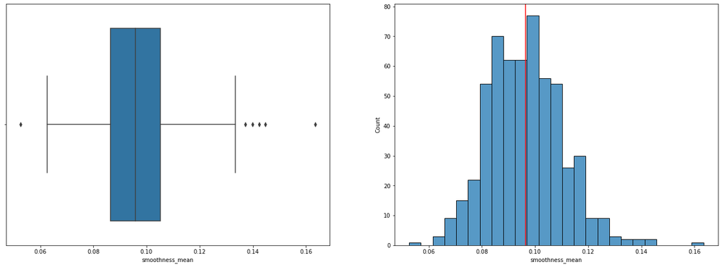

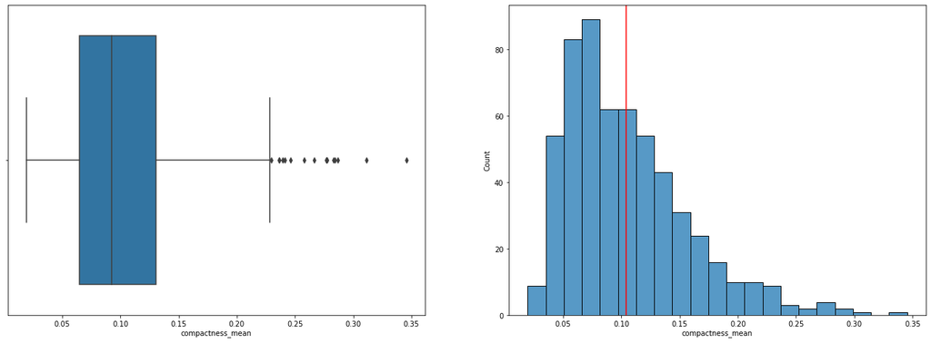

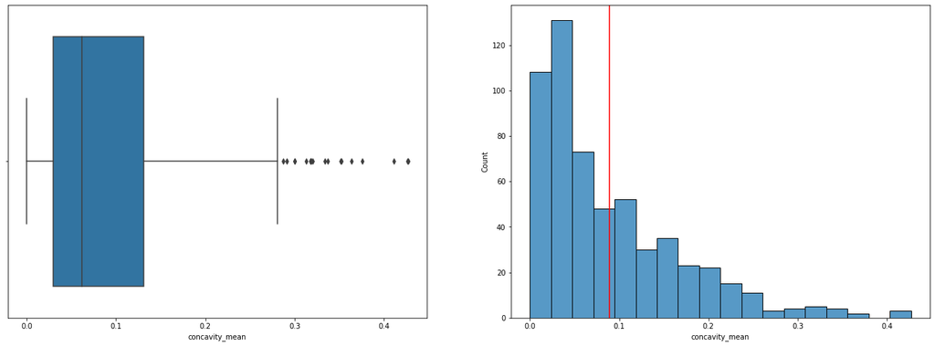

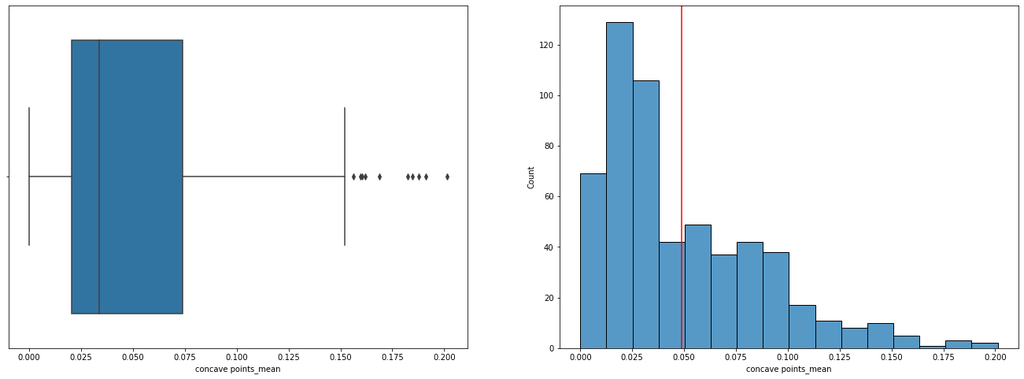

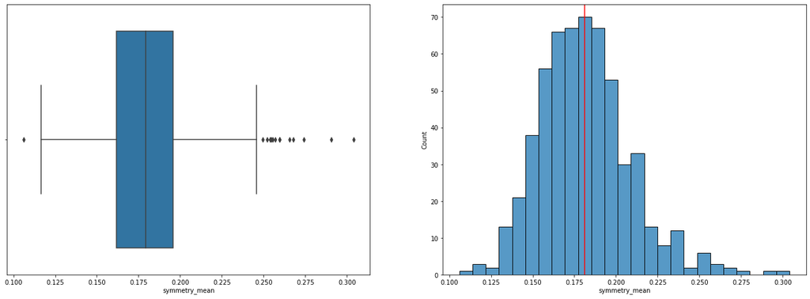

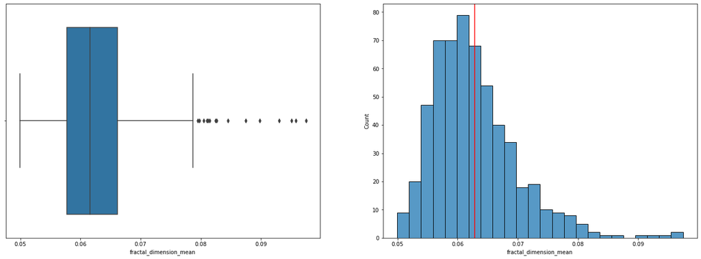

```python
columns =  ['radius_mean', 'texture_mean', 'perimeter_mean',
       'area_mean', 'smoothness_mean', 'compactness_mean', 'concavity_mean',
       'concave points_mean', 'symmetry_mean', 'fractal_dimension_mean']
for col in columns:
    f, (ax1, ax2) = plt.subplots(1,2, figsize = (23,8))
    sns.boxplot(x=df[col], ax=ax1);
    sns.histplot(x=df[col], ax=ax2);
#     we add a red line where the mean is:
    plt.axvline(x=df[col].mean(),color="red")
```

### I don't see here unusual things .... there are some outliers in part of the plots, some of the plots are right skwed, and some close to simmetrical. The main thing which interest us is the connection between this parameters to the malingnancy , so we will go now to see what are the variables with the correlation to it.

## Bivariate Exploration

> we would explore part of the variables at first, so we will build a new dataframe

```python
df_small = df[columns+['id','diagnosis']]
df_small.set_index('id',inplace=True)
df_small.head(2)
```

| id | radius_mean | texture_mean | perimeter_mean | area_mean | smoothness_mean | compactness_mean | concavity_mean | concave points_mean | symmetry_mean | fractal_dimension_mean | diagnosis |
| --- | --- | --- | --- | --- | --- | --- | --- | --- | --- | --- | --- |
| 842302 | 17.99 | 10.38 | 122.8 | 1001.0 | 0.11840 | 0.27760 | 0.3001 | 0.14710 | 0.2419 | 0.07871 | M |
| 842517 | 20.57 | 17.77 | 132.9 | 1326.0 | 0.08474 | 0.07864 | 0.0869 | 0.07017 | 0.1812 | 0.05667 | M |

```python
# in some of the parameters there are great differences in the size between B and M.
# first we will see it in numbers, after this in visualization:
diff_m_b = df_small.groupby('diagnosis').describe().transpose().loc[(slice(None),['mean','min','max','std']),:].unstack()
diff_m_b
```

| diagnosis | B mean | B std | B min | B max | M mean | M std | M min | M max |
| --- | --- | --- | --- | --- | --- | --- | --- | --- |
| radius_mean | 12.146524 | 1.780512 | 6.98100 | 17.85000 | 17.462830 | 3.203971 | 10.95000 | 28.11000 |
| texture_mean | 17.914762 | 3.995125 | 9.71000 | 33.81000 | 21.604906 | 3.779470 | 10.38000 | 39.28000 |
| perimeter_mean | 78.075406 | 11.807438 | 43.79000 | 114.60000 | 115.365377 | 21.854653 | 71.90000 | 188.50000 |
| area_mean | 462.790196 | 134.287118 | 143.50000 | 992.10000 | 978.376415 | 367.937978 | 361.60000 | 2501.00000 |
| smoothness_mean | 0.092478 | 0.013446 | 0.05263 | 0.16340 | 0.102898 | 0.012608 | 0.07371 | 0.14470 |
| compactness_mean | 0.080085 | 0.033750 | 0.01938 | 0.22390 | 0.145188 | 0.053987 | 0.04605 | 0.34540 |
| concavity_mean | 0.046058 | 0.043442 | 0.00000 | 0.41080 | 0.160775 | 0.075019 | 0.02398 | 0.42680 |
| concave points_mean | 0.025717 | 0.015909 | 0.00000 | 0.08534 | 0.087990 | 0.034374 | 0.02031 | 0.20120 |
| symmetry_mean | 0.174186 | 0.024807 | 0.10600 | 0.27430 | 0.192909 | 0.027638 | 0.13080 | 0.30400 |
| fractal_dimension_mean | 0.062867 | 0.006747 | 0.05185 | 0.09575 | 0.062680 | 0.007573 | 0.04996 | 0.09744 |

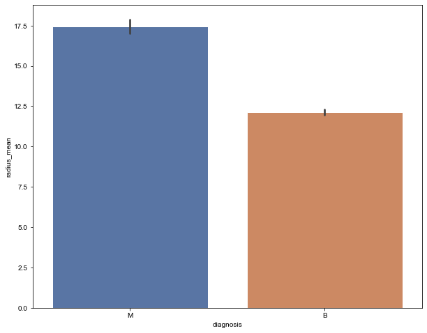

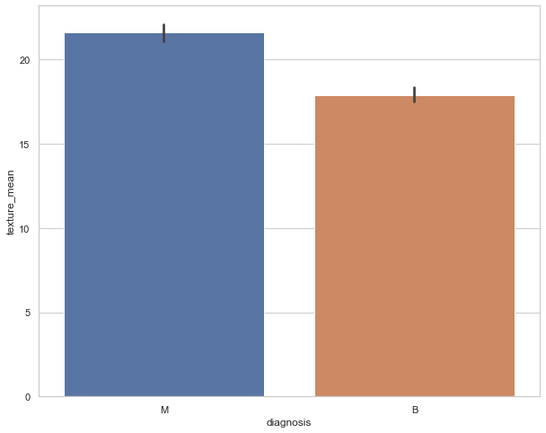

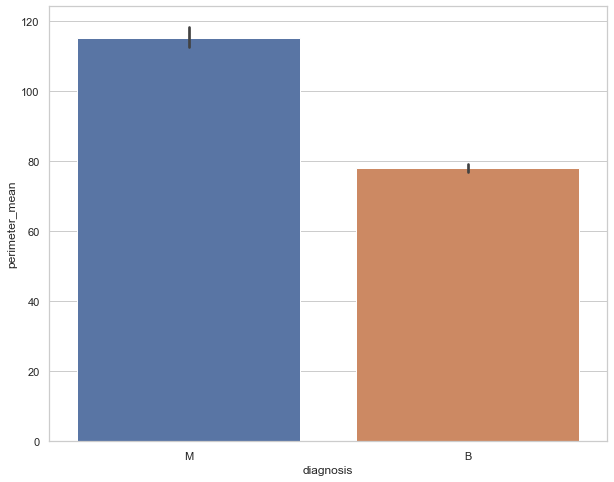

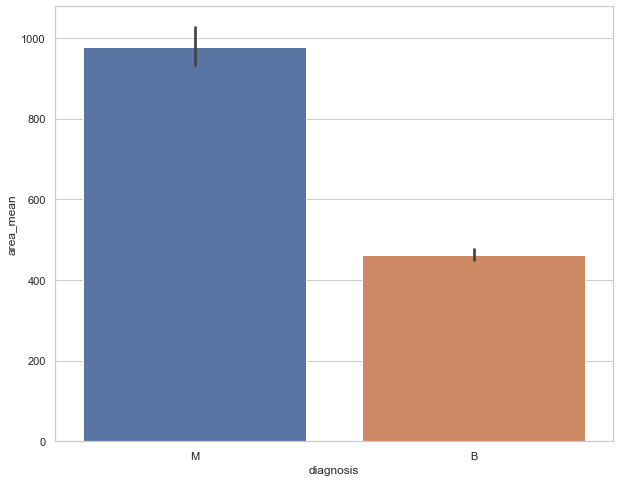

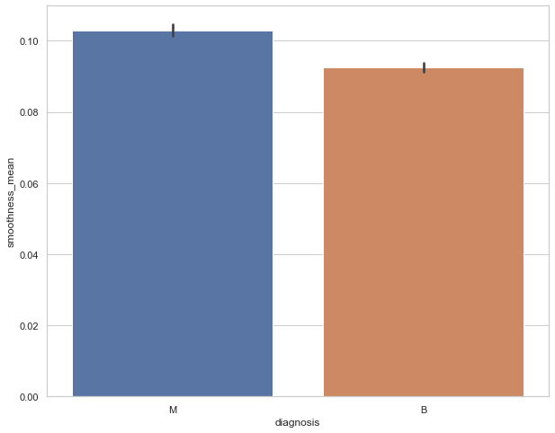

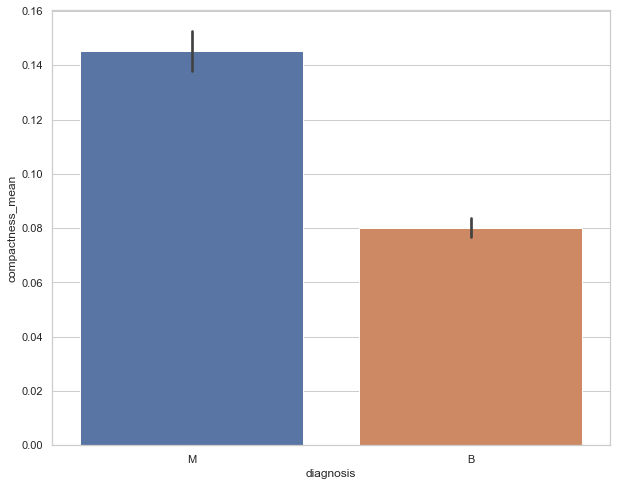

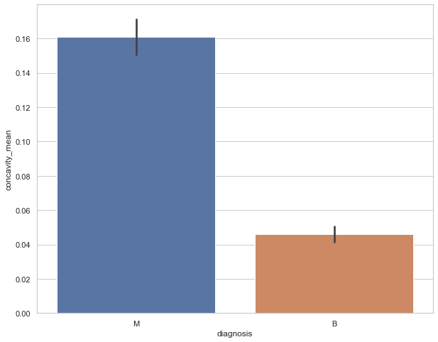

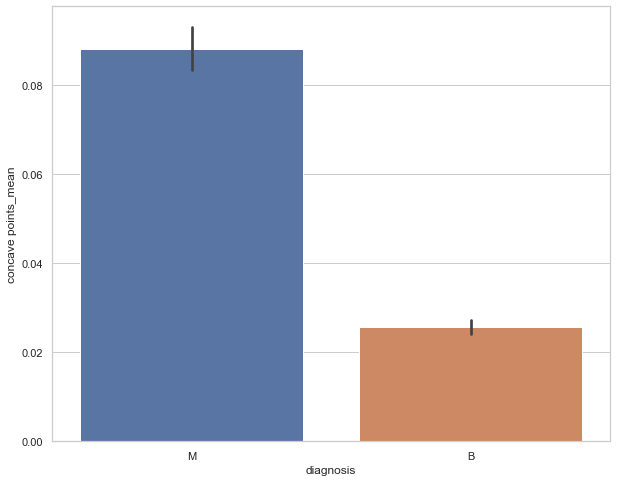

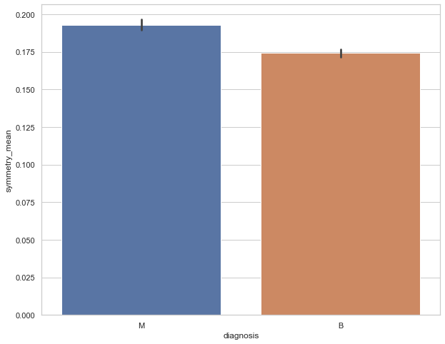

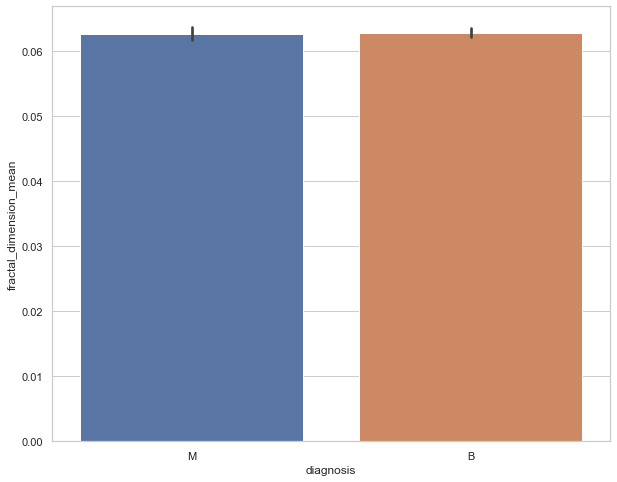

```python
# first we will create a bar plots:
for col in columns:
    f, ax = plt.subplots(1,1, figsize = (10,8))
    sns.set_theme(style="whitegrid")
    sns.barplot(ax=ax, x="diagnosis", y=col, data=df_small)
```

#### we see some diferences in the sizes, but to see it better and to explore overlapping, we will create another plots:

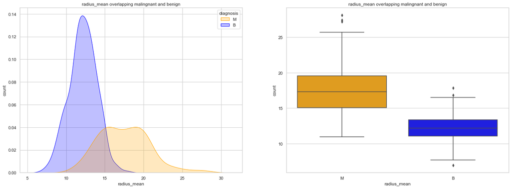

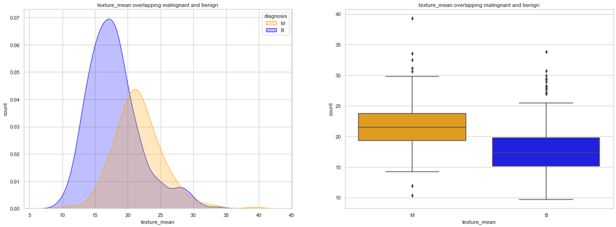

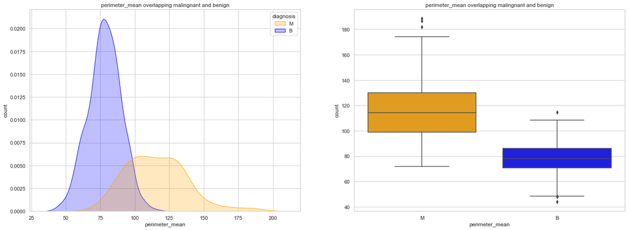

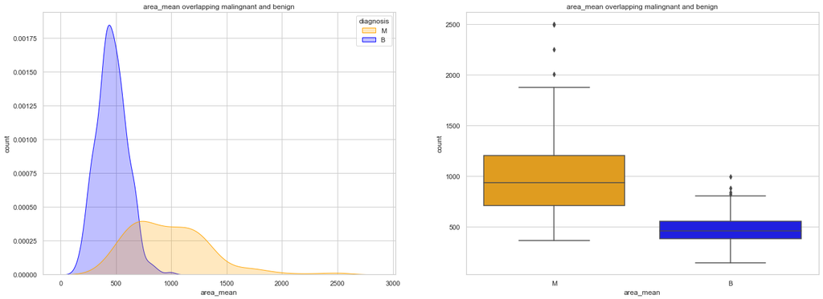

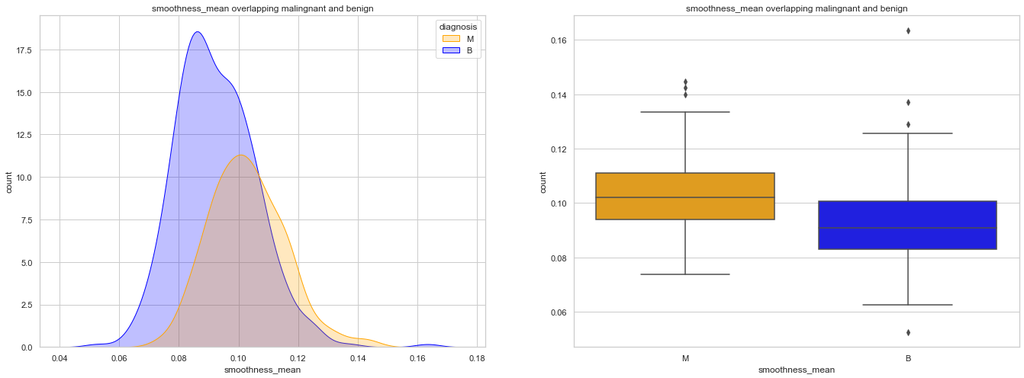

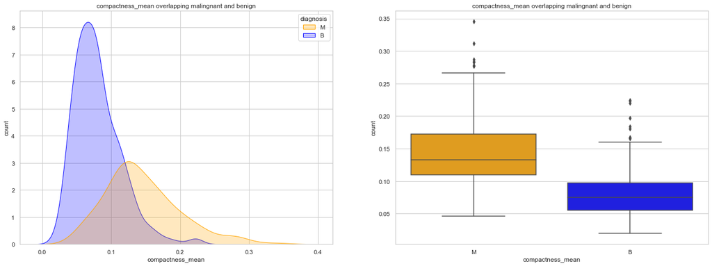

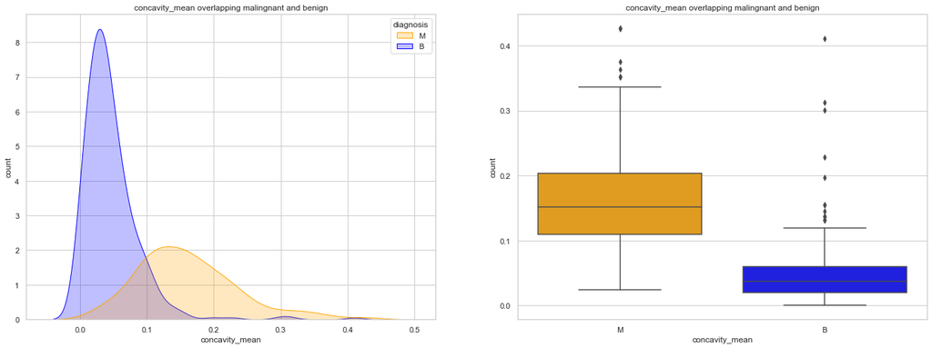

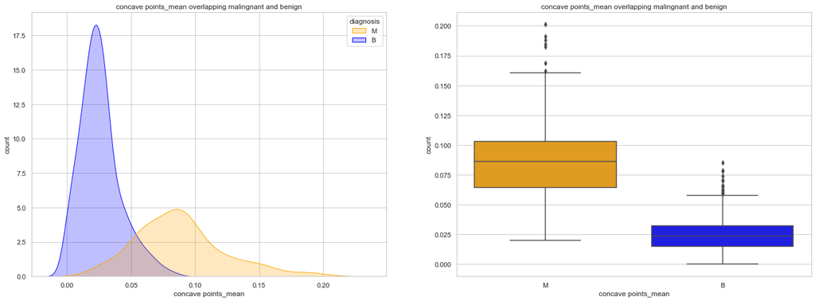

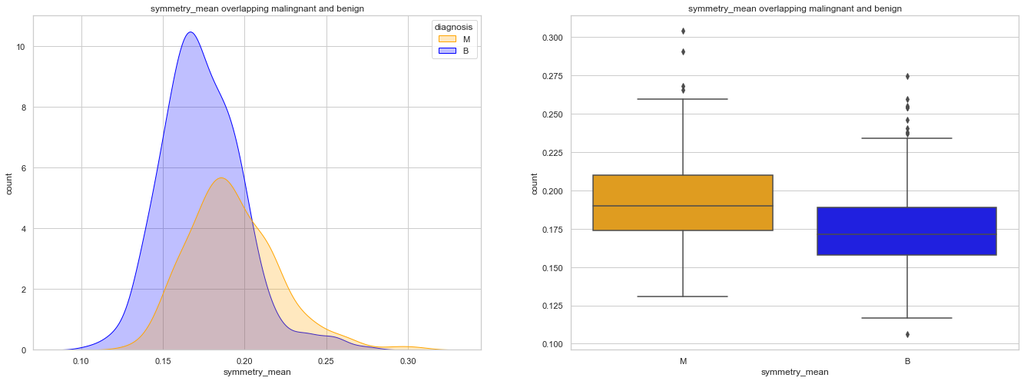

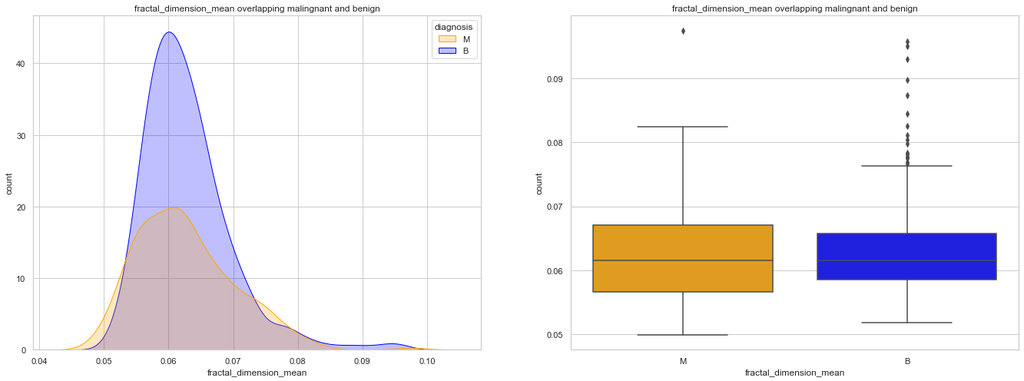

```python
for col in columns:
    fig, (ax1,ax2) = plt.subplots(1, 2,figsize = (23,8))
    pal = ['orange', 'blue']
    sns.kdeplot(ax=ax1, data=df_small, x=col, hue="diagnosis",fill=True,palette=pal)
    sns.boxplot(ax=ax2, x="diagnosis", y=col, data=df_small,palette=pal)
    ax1.set(title=f"{col} overlapping malingnant and benign",xlabel=f"{col}",ylabel="count")
    ax2.set(title=f"{col} overlapping malingnant and benign",xlabel=f"{col}",ylabel="count")
```